# HW5

Mykola Chuprinskiy

2024-10-10

# Assignment

Write all your text and R code in an R markdown file and compile an html file whose ZIP file can be handed in on Blackboard.

# 1. Non-negative matrix factorization

In this part of the assignment, non-negative matrix factorization (NMF) is used to once again learn the components which drive the stock market. Now, instead of the closing prices, the numbers of shares traded for 5 recent years for 505 companies currently found on the S&P 500 index, are used.

The data for this exercise can be found in the file: volume stocks.dat. The first feature in this data file is name and gives an abbreviation of the company name. The features named v1 to v1259 are the numbers of shares traded on 1259 days within 5 recent years.

Import the data into R. Be aware that the data file is tab-delimited and that the first line in the data file contains the feature names. The feature name (the first column) is not relevant for the analysis and should be removed. Certain companies have missing values. Remove the companies with missing values and only use the complete cases (companies). Next, store the data in a matrix.

Apply NMF to the data matrix. Determine the dimension using the proportion of explained variance.

```r
# Importing and tidying the dataset
data <- read.delim("volume_stocks.dat", header = TRUE)
cleaned_data <- na.omit(data)
data_matrix <- as.matrix(cleaned_data[ , -1])

# Checking that the values are non-negative, as this is a requirement in Non-Negative Matrix Factorization
data_matrix[data_matrix < 0] <- 0
```

## (a) How many dimensions do you select?

```r
library(NMF)
```

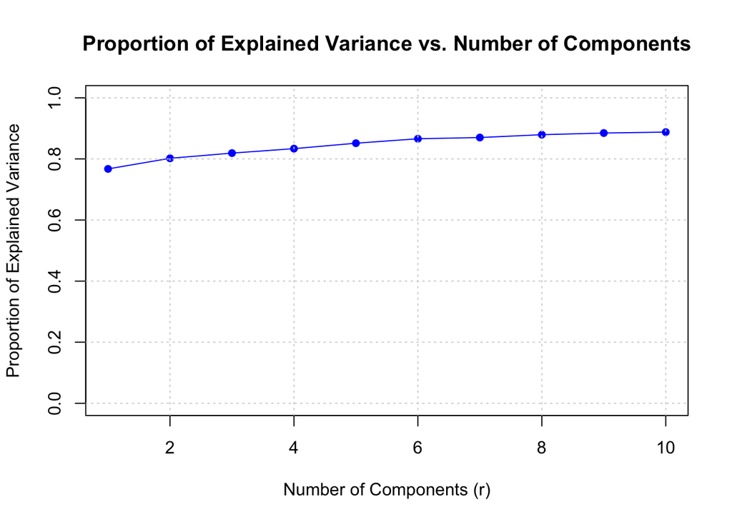

```r
# Applying Non-negative Matrix Factorization
# We decide the number of components
rank_range <- 1:10
n <- length(rank_range)
explained_variance <- numeric(n)
proportion_explained_variance <- numeric(n)

# Defining the total variance
total_variance <- sum(data_matrix^2)

# Defining the reconstructed matrix
reconstructed_matrix <- vector("list", n)

for (i in rank_range) {
  nmf_result <- nmf(data_matrix, i)

  reconstructed_matrix[[i]] <- fitted(nmf_result)
  explained_variance[i] <- sum(reconstructed_matrix[[i]]^2)
  proportion_explained_variance[i] <- explained_variance[i] / total_variance
}

# Now we plot it
plot(rank_range, proportion_explained_variance, type = "o", pch = 16, lty = 1,
     col = "blue", main = "Proportion of Explained Variance vs. Number of Components",
     xlab = "Number of Components (r)", ylab = "Proportion of Explained Variance",
     ylim = c(0, 1))
grid()
```

To determine the number of dimensions, we can look at the rank set in Non-Negative Matrix Factorization:

```r
rank_selected <- 6
cat("Selected number of dimensions (rank):", rank_selected)
```

```
## Selected number of dimensions (rank): 6
```

## (b) Give the proportion of explained variance for this number of dimensions

```r
# Now we want to see the proportion of explained variance
cat("Proportion of explained variance:", proportion_explained_variance[rank_selected])
```

```
## Proportion of explained variance: 0.8660009
```

## (c) Give the reconstruction error for this number of dimensions

```r
# I will be looking at the reconstruction error
nmf_result_selected <- nmf(data_matrix, rank_selected)
reconstructed_matrix_selected <- fitted(nmf_result_selected)
reconstruction_error_selected <- sqrt(sum((data_matrix - reconstructed_matrix_selected)^2))
cat("Reconstruction error:", reconstruction_error_selected, "\n")
```

```
## Reconstruction error: 2628704333
```

## (d) Calculate the correlation matrix of the finally selected dimensions

```r
# Now we are asked to find the correlation matrix
W <- basis(nmf_result_selected)
H <- coef(nmf_result_selected)
correlation_matrix_selected <- cor(W)
cat("Correlation matrix:", correlation_matrix_selected)
```

[output not shown]

## (e) Calculate the values of Hoyer’s sparseness coefficient for the features matrix and the coefficients matrix.

```r
# We will now define a function that will calculate the Hoyer's sparseness coefficient by using the formula
sparseness <- function(X) {
  n <- length(X)
  numerator <- sqrt(n) - sum(abs(X)) / sqrt(sum(X^2))
  denominator <- sqrt(n) - 1
  return(numerator / denominator)
}

W_sparseness <- sparseness(as.vector(W))
H_sparseness <- sparseness(as.vector(H))

cat("Hoyer's sparseness coefficient for W matrix:", W_sparseness, "\n")
```

```
## Hoyer's sparseness coefficient for W matrix: 0.6615743
```

```r
cat("Hoyer's sparseness coefficient for H matrix:", H_sparseness, "\n")
```

```
## Hoyer's sparseness coefficient for H matrix: 0.2394214
```

## (f) Produce heat maps for the features matrix and the coefficients matrix

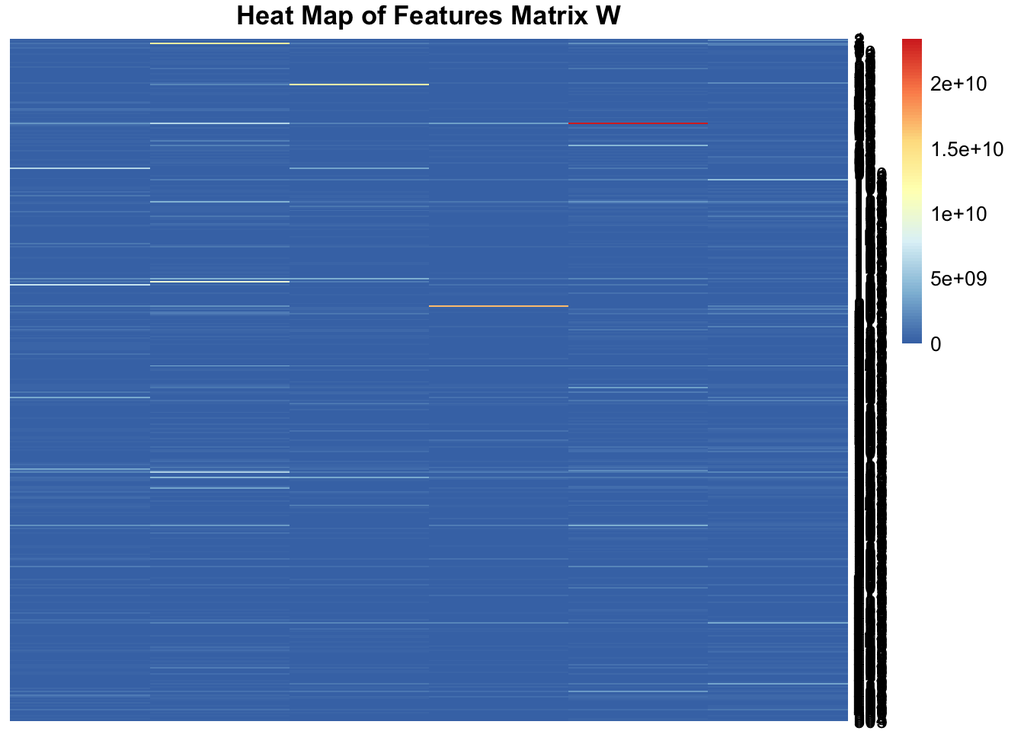

```r
library(pheatmap)

# Heat map for the features matrix W
pheatmap(W, main = "Heat Map of Features Matrix W", cluster_rows = FALSE, cluster_cols = FALSE)
```

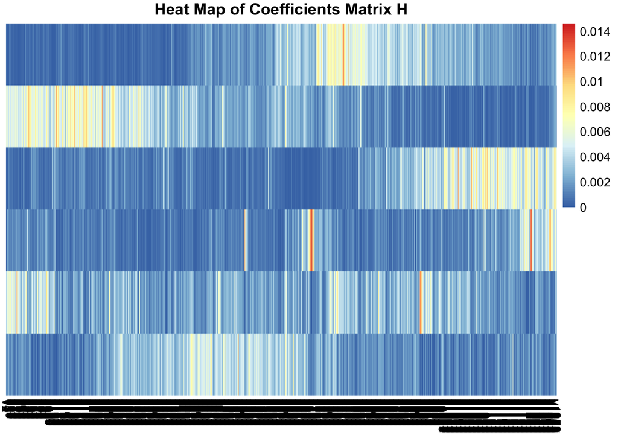

```r
# Heat map for the coefficients matrix H
pheatmap(H, main = "Heat Map of Coefficients Matrix H", cluster_rows = FALSE, cluster_cols = FALSE)
```

# 2. Probabilistic latent semantic analysis

In this part of the assignment, probabilistic latent semantic analysis is applied to the data file benthos.txt. The data set consists of abundances of 10 marine species near an oilfield in the North Sea at 13 sites (the columns in the data file). The first 11 columns give the data for polluted sites. The last two columns give the data for unpolluted reference sites. Import the data into R and store the data as a matrix.

```r
# Importing and tidying of the data
library(topicmodels)
library(tm)
data_2 <- read.delim("benthons.txt", header = F)
data_matrix_2 <- as.matrix(data_2)
data_matrix_2[data_matrix_2 < 0] <- 0

dtm_2 <- as.DocumentTermMatrix(Matrix::Matrix(data_matrix_2, sparse = TRUE), weighting = weightTf)
```

Carry out a probabilistic latent semantic analysis. Use the proportion of explained variance to determine the number of latent classes.

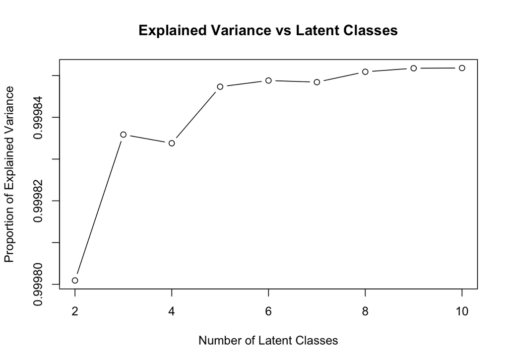

```r
# We define the range for the number of latent classes
num_latent_classes <- 2:10
n_2 <- length(num_latent_classes)  # Define n_2 as the length of the number of latent classes

# Now we initialize vectors to store the explained variance for each number of latent classes
explained_variance_2 <- numeric(n_2)
proportion_explained_variance_2 <- numeric(n_2)

# Now we find the total variance based on the normalized data
total_variance <- sum((data_matrix_2 - mean(data_matrix_2))^2)

# Now we perform a loop through different latent classes
for (i_2 in 1:n_2) {
  # Perform probabilistic latent semantic analysis using LDA
  plsa_model <- LDA(dtm_2, k = num_latent_classes[i_2], method = "VEM")
  posterior_lda <- posterior(plsa_model)

  # Reconstruct the matrix using the posterior distributions
  reconstructed_matrix <- posterior_lda$topics %*% posterior_lda$terms

  # Normalize the original data matrix and the reconstructed matrix
  data_matrix_2 <- scale(data_matrix_2, center = TRUE, scale = TRUE)
  reconstructed_matrix <- scale(reconstructed_matrix, center = TRUE, scale = TRUE)

  # Now we find the residual variance, which is the difference between the original matrix and the reconstructed matrix
  residual_variance <- sum((data_matrix_2 - reconstructed_matrix)^2)

  # Calculate the explained variance for the current number of latent classes
  explained_variance_2[i_2] <- total_variance - residual_variance
  proportion_explained_variance_2[i_2] <- explained_variance_2[i_2] / total_variance
}

# Now we make the plot !
plot(num_latent_classes, proportion_explained_variance_2, type = "b",
     xlab = "Number of Latent Classes",
     ylab = "Proportion of Explained Variance",
     main = "Explained Variance vs Latent Classes")
```

## (a) How many latent classes do you select? Why?

```r
# We select 4
optimal_latent_classes <- 4
cat("Number of latent classes selected:", optimal_latent_classes)
```

```
## Number of latent classes selected: 4
```